# IMDB Movie Review Prediction Model

## 1 Defining the Problem

In this project, we define the problem as creating a high accuracy binary classification model that would predict whether an International Movie Data Base (IMDB) review is positive or negative. The data is obtained from tensorflow keras library's official datasets. The input data is 50,000 movie reviews that were manually labeled as positive or negative. The database is divided in half into 25,000 training data and 25,000 testing data with each dataset having 50% positive and 50% negative reviews. The binary classification model can be predicted using this input dataset. Finally, the dataset is easily accessible and informative to create a proper model.

## 2 Measure of Success

In simple binary classification problems it is usually easiest to use accuracy especially in this dataset that the data is very balanced and predicting the negative reviews correctly is as important as predicting the positive reviews correctly. Hence, the aim is to create a model with high accuray and the fine-tuning of the hyperparameters depends on the accuracy acheived in each training.

## 3 Evaluation Protocol

Using simple hold-out evaluation in this project should work well since we have a large dataset available to evaluate the model. To do this, I will use the following code: model.evaluate(x_val,y_val) to explicity evaluate the model on the held-out validation data set as stated in DLWP.

## 4 Preparing Data

### 4.1 Importing the Dataset

```python
#from DLWP/Lectures
import tensorflow as tf
from tensorflow import keras
from tensorflow.keras.datasets import imdb

#importing the dataset
(train_data, train_labels), (test_data, test_labels) = imdb.load_data(num_words=10000)
```

### 4.2 Exploring the Data

```python
#from DLWP/Lectures
#Changed index
print(train_data[50])
```

```
[1, 13, 165, 219, 14, 20, 33, 6, 750, 17, 515, 17, 13, 2675, 4, 2, 61, 278, 59, 301, 107, 715, 13, 69, 115, 557, 33, 6, 750, 159, 42, 237, 57, 2, 17, 515, 17, 13, 557, 148, 715, 13, 144, 28, 43, 2, 5458, 5458, 8, 61, 2208, 5, 825, 344, 21, 57, 2, 13, 435, 11, 5, 296, 4, 20, 14, 20, 161, 97, 259, 11,…
```

```python
#from DLWP/Lectures
#Changed index
word_index = imdb.get_word_index()
reverse_word_index = dict([(value,key) for (key,value) in word_index.items()])
decoded_review = ' '.join([reverse_word_index.get(i-3,'?') for i in train_data[50]])
print(decoded_review)
```

```
? i actually saw this movie at a theater as soon as i handed the ? my money she said two words i had never heard at a theater before or since no ? as soon as i heard those words i should have just ? bye bye to my cash and gone home but no ? i went in and watched the movie this movie didn't make anyo…
```

```python
#from DLWP/Lectures
#Changed index
decoded_review = ' '.join([reverse_word_index.get(i-3,'?') for i in train_data[111]])
print(decoded_review, '\n\n', 'label:', train_labels[111])
```

```
? when people ask me why do i like movies so much i usually respond have you seen the art gallery sequence in de palma's dressed to kill that scene alone pretty much represents everything i want to see in a film if i was a film director that would be the kind of thing i'd like to do pure cinema is o…

 label: 1
```

### 4.3 Vectorizing the Data

We will vectorize the dataset to be able to manipulate the data properly using the simple code below:

```python
#from DLWP/Lectures
import numpy as np

def vectorize_sequences(sequences, dimension = 10000):
    results = np.zeros( (len(sequences), dimension) )
    for i, sequence in enumerate(sequences):
        results[i, sequence] = 1.
    return results

x_train = vectorize_sequences(train_data)
x_test = vectorize_sequences(test_data)

y_train = np.asarray(train_labels).astype('float32')
y_test =  np.asarray(test_labels).astype('float32')
```

## 5 Model Development

We are assuming a baseline model to have a 50% accuracy and we attempt to create a model that has performs better than the baseline model.

```python
#Inspired by DLWP/Lecture - Changed the number of layers and layer capacity
from keras import models
from keras import layers

model = models.Sequential()
model.add(layers.Dense(32, activation='relu', input_shape=(10000,)))
model.add(layers.Dense(32, activation='relu'))
model.add(layers.Dense(32, activation='relu'))
model.add(layers.Dense(1, activation='sigmoid'))

model.compile(optimizer='rmsprop',
              loss = 'binary_crossentropy',
              metrics = ['accuracy'])
```

```python
model.summary()
```

```
Model: "sequential"
_________________________________________________________________
 Layer (type)                Output Shape              Param #
=================================================================
 dense (Dense)               (None, 32)                320032

 dense_1 (Dense)             (None, 32)                1056

 dense_2 (Dense)             (None, 32)                1056

 dense_3 (Dense)             (None, 1)                 33

=================================================================
Total params: 322,177
Trainable params: 322,177
Non-trainable params: 0
_________________________________________________________________
```

```python
#Inspired by DLWP/Lecture - Changed the number of epochs
x_val = x_train[:10000]
partial_x_train = x_train[10000:]
y_val = y_train[:10000]
partial_y_train = y_train[10000:]

history = model.fit(partial_x_train, partial_y_train, epochs = 10, batch_size = 512, validation_data= (x_val, y_val))
results = model.evaluate(x_val, y_val)
```

```python
history_dict = history.history
history_dict.keys()
```

```
dict_keys(['loss', 'accuracy', 'val_loss', 'val_accuracy'])
```

```python
#defining plot loss and accuracy functions against the training and validation dataset
# Inspired by lectures/lab - I created my own function to stop repeating the plot function
import matplotlib.pyplot as plt

def plot_loss(loss_values, val_loss_values, epochs):
    plt.plot(epochs, loss_values, 'ro', label='Training loss')
    plt.plot(epochs, val_loss_values, 'r', label='Validation loss')
    plt.title('Training and Validation Loss')
    plt.xlabel('Epochs')
    plt.ylabel('Loss')
    plt.legend()
    plt.show()

def plot_acc(acc, val_acc, epochs):
    plt.plot(epochs, acc, 'go', label='Training acc')
    plt.plot(epochs, val_acc, 'g', label='Validation acc')
    plt.title('Training and Validation Accuracy')
    plt.xlabel('Epochs')
    plt.ylabel('Accuracy')
    plt.legend()
    plt.show()
```

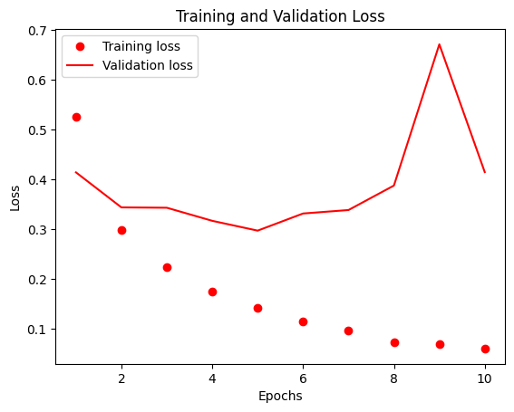

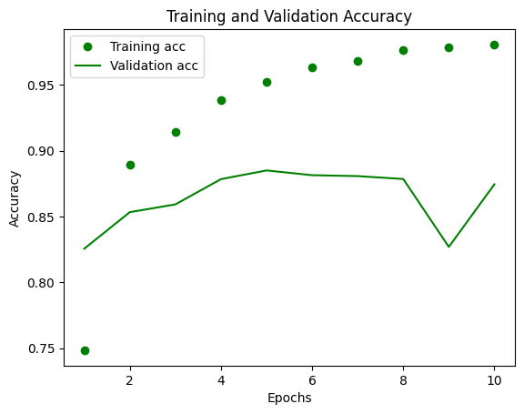

```python
history_dict = history.history
loss_values = history_dict['loss']
val_loss_values = history_dict['val_loss']
acc = history_dict['accuracy']
val_acc = history_dict['val_accuracy']
epochs = range(1, len(loss_values) + 1)

plot_loss(loss_values, val_loss_values,epochs)
plot_acc(acc, val_acc,epochs)
```

We have an accuracy of 87.45% as our initial model. We will tweak this model to find the best accuracy. As you can see above the accuracy between the training and evaluation dataset is vast - we aim to close this gap.

## 6 Scaling up: Overfit Model Development

In this section, we overfit the model by tweaking different parameters.

### 6.1 Adding Layers

```python
#adding one additional relu layer
model = models.Sequential()
model.add(layers.Dense(32, activation='relu', input_shape=(10000,)))
model.add(layers.Dense(32, activation='relu'))
model.add(layers.Dense(32, activation='relu'))
model.add(layers.Dense(32, activation='relu'))
model.add(layers.Dense(1, activation='sigmoid'))

model.compile(optimizer='rmsprop',
              loss = 'binary_crossentropy',
              metrics = ['accuracy'])

history = model.fit(partial_x_train, partial_y_train, epochs = 10, batch_size = 512, validation_data= (x_val, y_val))
results = model.evaluate(x_val, y_val)
```

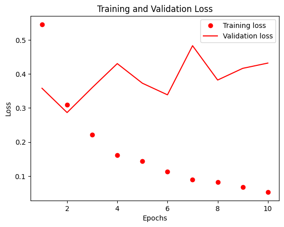

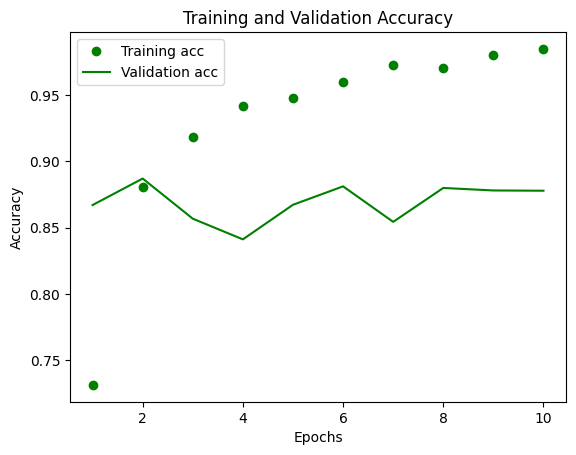

```python
history_dict = history.history
loss_values = history_dict['loss']
val_loss_values = history_dict['val_loss']
acc = history_dict['accuracy']
val_acc = history_dict['val_accuracy']
epochs = range(1, len(loss_values) + 1)

plot_loss(loss_values, val_loss_values,epochs)
plot_acc(acc, val_acc,epochs)
```

Adding one more layer seems to increase the accuracy by a small amount from 87.45% to 87.78%.

### 6.2 Making the Layers Larger

```python
#Increase the layer capacity to 64
model = models.Sequential()
model.add(layers.Dense(64, activation='relu', input_shape=(10000,)))
model.add(layers.Dense(64, activation='relu'))
model.add(layers.Dense(64, activation='relu'))
model.add(layers.Dense(64, activation='relu'))
model.add(layers.Dense(1, activation='sigmoid'))

model.compile(optimizer='rmsprop',
              loss = 'binary_crossentropy',
              metrics = ['accuracy'])

history = model.fit(partial_x_train, partial_y_train, epochs = 10, batch_size = 512, validation_data= (x_val, y_val))
results = model.evaluate(x_val,y_val)
```

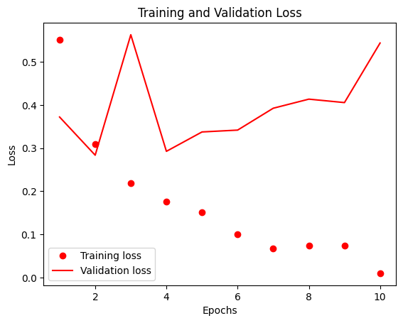

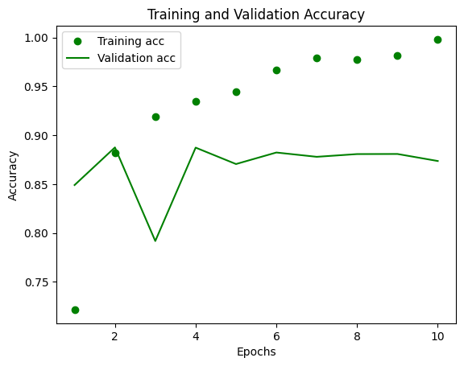

```python
history_dict = history.history
loss_values = history_dict['loss']
val_loss_values = history_dict['val_loss']
acc = history_dict['accuracy']
val_acc = history_dict['val_accuracy']
epochs = range(1, len(loss_values) + 1)

plot_loss(loss_values, val_loss_values,epochs)
plot_acc(acc, val_acc,epochs)
```

```python
#Increase the layer capacity to 256
model = models.Sequential()
model.add(layers.Dense(256, activation='relu', input_shape=(10000,)))
model.add(layers.Dense(256, activation='relu'))
model.add(layers.Dense(256, activation='relu'))
model.add(layers.Dense(256, activation='relu'))
model.add(layers.Dense(1, activation='sigmoid'))

model.compile(optimizer='rmsprop',
              loss = 'binary_crossentropy',
              metrics = ['accuracy'])

history = model.fit(partial_x_train, partial_y_train, epochs = 10, batch_size = 512, validation_data= (x_val, y_val))
results = model.evaluate(x_val,y_val)
```

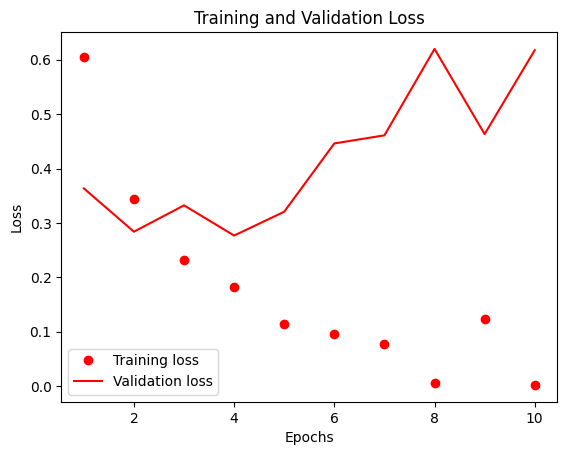

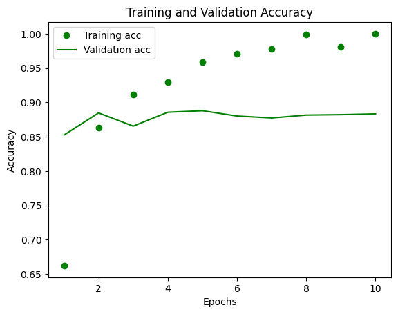

```python
history_dict = history.history
loss_values = history_dict['loss']
val_loss_values = history_dict['val_loss']
acc = history_dict['accuracy']
val_acc = history_dict['val_accuracy']
epochs = range(1, len(loss_values) + 1)

plot_loss(loss_values, val_loss_values,epochs)
plot_acc(acc, val_acc,epochs)
```

Increasing the capacity of the layers to 256 increased the accuracy to 88.33%. This is a huge improvement. Let's try 512 out of curiosity:

```python
#Increase the layer capacity to 512
model = models.Sequential()
model.add(layers.Dense(512, activation='relu', input_shape=(10000,)))
model.add(layers.Dense(512, activation='relu'))
model.add(layers.Dense(512, activation='relu'))
model.add(layers.Dense(512, activation='relu'))
model.add(layers.Dense(1, activation='sigmoid'))

model.compile(optimizer='rmsprop',
              loss = 'binary_crossentropy',
              metrics = ['accuracy'])

history = model.fit(partial_x_train, partial_y_train, epochs = 10, batch_size = 512, validation_data= (x_val, y_val))
results = model.evaluate(x_val,y_val)
```

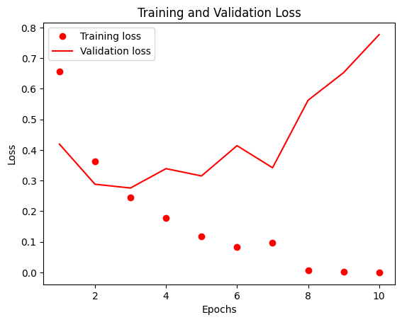

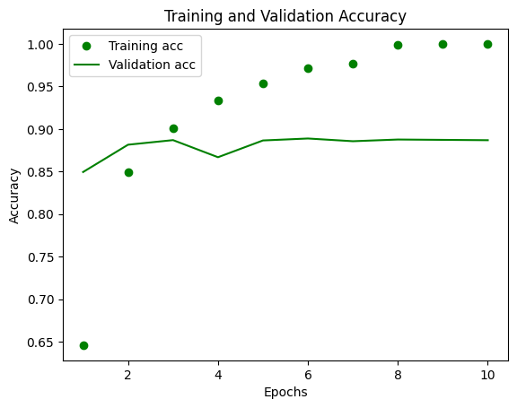

```python
history_dict = history.history
loss_values = history_dict['loss']
val_loss_values = history_dict['val_loss']
acc = history_dict['accuracy']
val_acc = history_dict['val_accuracy']
epochs = range(1, len(loss_values) + 1)

plot_loss(loss_values, val_loss_values,epochs)
plot_acc(acc, val_acc,epochs)
```

### 6.3 Train for More Epochs

```python
# increase the number of epochs from 10 to 20
model = models.Sequential()
model.add(layers.Dense(512, activation='relu', input_shape=(10000,)))
model.add(layers.Dense(512, activation='relu'))
model.add(layers.Dense(512, activation='relu'))
model.add(layers.Dense(512, activation='relu'))
model.add(layers.Dense(1, activation='sigmoid'))

model.compile(optimizer='rmsprop',
              loss = 'binary_crossentropy',
              metrics = ['accuracy'])

history = model.fit(partial_x_train, partial_y_train, epochs = 20, batch_size = 512, validation_data= (x_val, y_val))
results = model.evaluate(x_val,y_val)
```

[figure not shown]

[figure not shown]

```python
history_dict = history.history
loss_values = history_dict['loss']
val_loss_values = history_dict['val_loss']
acc = history_dict['accuracy']
val_acc = history_dict['val_accuracy']
epochs = range(1, len(acc) + 1)

plot_loss(loss_values, val_loss_values,epochs)
plot_acc(acc, val_acc,epochs)
```

## 7 Regularizing the Model & Tuning Hyperparameters

In this section we tweak the hyperparameters and different layers. I will stop plotting loss and accuracy for each hyperparameter to save space and only plot the final model.

### 7.1 Add Dropout Layer

```python
# Inspired by DLWP
# Adding Dropout 0.1
model = models.Sequential()
model.add(layers.Dense(512, activation='relu', input_shape=(10000,)))
model.add(layers.Dropout(0.1))
model.add(layers.Dense(512, activation='relu'))
model.add(layers.Dropout(0.1))
model.add(layers.Dense(512, activation='relu'))
model.add(layers.Dropout(0.1))
model.add(layers.Dense(512, activation='relu'))
model.add(layers.Dropout(0.1))
model.add(layers.Dense(1, activation='sigmoid'))

model.compile(optimizer='rmsprop',
              loss = 'binary_crossentropy',
              metrics = ['accuracy'])

history = model.fit(partial_x_train, partial_y_train, epochs = 20, batch_size = 512, validation_data= (x_val, y_val))
results = model.evaluate(x_val,y_val)
```

Adding a dropout layer of 0.1 did't change the accuracy by much - let's try 0.2:

```python
# Adding Dropout 0.2
model = models.Sequential()
model.add(layers.Dense(512, activation='relu', input_shape=(10000,)))
model.add(layers.Dropout(0.2))
model.add(layers.Dense(512, activation='relu'))
model.add(layers.Dropout(0.2))
model.add(layers.Dense(512, activation='relu'))
model.add(layers.Dropout(0.2))
model.add(layers.Dense(512, activation='relu'))
model.add(layers.Dropout(0.2))
model.add(layers.Dense(1, activation='sigmoid'))

model.compile(optimizer='rmsprop',
              loss = 'binary_crossentropy',
              metrics = ['accuracy'])

history = model.fit(partial_x_train, partial_y_train, epochs = 20, batch_size = 512, validation_data= (x_val, y_val))
results = model.evaluate(x_val,y_val)
```

```python
# Adding Dropout 0.3
model = models.Sequential()
model.add(layers.Dense(512, activation='relu', input_shape=(10000,)))
model.add(layers.Dropout(0.3))
model.add(layers.Dense(512, activation='relu'))
model.add(layers.Dropout(0.3))
model.add(layers.Dense(512, activation='relu'))
model.add(layers.Dropout(0.3))
model.add(layers.Dense(512, activation='relu'))
model.add(layers.Dropout(0.3))
model.add(layers.Dense(1, activation='sigmoid'))

model.compile(optimizer='rmsprop',
              loss = 'binary_crossentropy',
              metrics = ['accuracy'])

history = model.fit(partial_x_train, partial_y_train, epochs = 20, batch_size = 512, validation_data= (x_val, y_val))
results = model.evaluate(x_val,y_val)
```

```python
# Adding Dropout 0.4
model = models.Sequential()
model.add(layers.Dense(512, activation='relu', input_shape=(10000,)))
model.add(layers.Dropout(0.4))
model.add(layers.Dense(512, activation='relu'))
model.add(layers.Dropout(0.4))
model.add(layers.Dense(512, activation='relu'))
model.add(layers.Dropout(0.4))
model.add(layers.Dense(512, activation='relu'))
model.add(layers.Dropout(0.4))
model.add(layers.Dense(1, activation='sigmoid'))

model.compile(optimizer='rmsprop',
              loss = 'binary_crossentropy',
              metrics = ['accuracy'])

history = model.fit(partial_x_train, partial_y_train, epochs = 20, batch_size = 512, validation_data= (x_val, y_val))
results = model.evaluate(x_val,y_val)
```

```python
# Adding Dropout 0.5
model = models.Sequential()
model.add(layers.Dense(512, activation='relu', input_shape=(10000,)))
model.add(layers.Dropout(0.5))
model.add(layers.Dense(512, activation='relu'))
model.add(layers.Dropout(0.5))
model.add(layers.Dense(512, activation='relu'))
model.add(layers.Dropout(0.5))
model.add(layers.Dense(512, activation='relu'))
model.add(layers.Dropout(0.5))
model.add(layers.Dense(1, activation='sigmoid'))

model.compile(optimizer='rmsprop',
              loss = 'binary_crossentropy',
              metrics = ['accuracy'])

history = model.fit(partial_x_train, partial_y_train, epochs = 20, batch_size = 512, validation_data= (x_val, y_val))
results = model.evaluate(x_val,y_val)
```

It seems like the drop out value of 0.3 to give us the highest accuracy. I am curious to try increasing the drop out value in each later by 0.1 and decreasing it also by 0.1 and observe the effect.

```python
# Increasing Dropout Value by 0.1
model = models.Sequential()
model.add(layers.Dense(512, activation='relu', input_shape=(10000,)))
model.add(layers.Dropout(0.1))
model.add(layers.Dense(512, activation='relu'))
model.add(layers.Dropout(0.2))
model.add(layers.Dense(512, activation='relu'))
model.add(layers.Dropout(0.3))
model.add(layers.Dense(512, activation='relu'))
model.add(layers.Dropout(0.4))
model.add(layers.Dense(1, activation='sigmoid'))

model.compile(optimizer='rmsprop',
              loss = 'binary_crossentropy',
              metrics = ['accuracy'])

history = model.fit(partial_x_train, partial_y_train, epochs = 20, batch_size = 512, validation_data= (x_val, y_val))
results = model.evaluate(x_val,y_val)
```

```python
# Decreasing Dropout Value by 0.1
model = models.Sequential()
model.add(layers.Dense(512, activation='relu', input_shape=(10000,)))
model.add(layers.Dropout(0.4))
model.add(layers.Dense(512, activation='relu'))
model.add(layers.Dropout(0.3))
model.add(layers.Dense(512, activation='relu'))
model.add(layers.Dropout(0.2))
model.add(layers.Dense(512, activation='relu'))
model.add(layers.Dropout(0.1))
model.add(layers.Dense(1, activation='sigmoid'))

model.compile(optimizer='rmsprop',
              loss = 'binary_crossentropy',
              metrics = ['accuracy'])

history = model.fit(partial_x_train, partial_y_train, epochs = 20, batch_size = 512, validation_data= (x_val, y_val))
results = model.evaluate(x_val,y_val)
```

Not much improvement is observed - therefore we choose dropout value of 0.3.